# Análisis de los precios de viviendas en el área metropolitana de Nueva York

#### Este segmento de código utiliza la librería matplotlib para crear un gráfico de barras con el DataFrame 'df3', donde en el eje x se encuentra la columna 'RegionName' y en el eje y se encuentra la columna 'PriceMean', se agrega el título "Promedio de precios mas altos por región" y las etiquetas "Región" y "Promedio de precios" al eje x e y respectivamente.

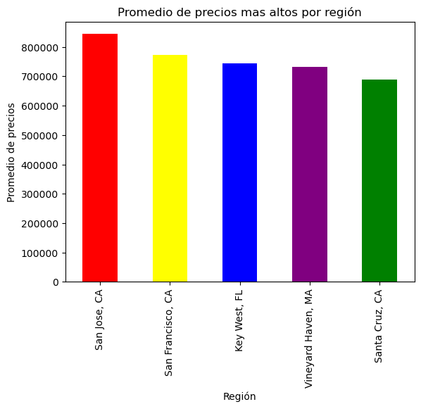

```python
colores = ['red', 'yellow', 'blue', 'purple', 'green']

# utilizamos el método 'plot' con el argumento kind='bar' para crear un gráfico de barras
df3.plot(x='RegionName', y='PriceMean', kind='bar', legend=False, color=colores)

# agregamos título y etiquetas a los ejes
plt.title("Promedio de precios mas altos por región")
plt.xlabel("Región")
plt.ylabel("Promedio de precios")

# mostramos el gráfico
plt.show()
```

```python
# ordenamos el DataFrame 'df2' en orden ascendente utilizando la columna 'Mean' como criterio de ordenamiento
df4 = df2.sort_values(by='PriceMean', ascending=True)

# seleccionamos las primeras 5 filas del DataFrame ordenado
df4 = df4.head(5)

# imprimimos el DataFrame 'df4' para mostrar las primeras 5 filas del DataFrame 'df2' ordenadas de manera ascendente utilizando la columna 'Mean' como criterio de ordenamiento
print(df4)
```

```
            RegionName  PriceMean
878         Helena, AR      33868
804         Camden, AR      52352
731          Selma, AL      53313
834   Forrest City, AR      53808
823  Bennettsville, SC      54638
```

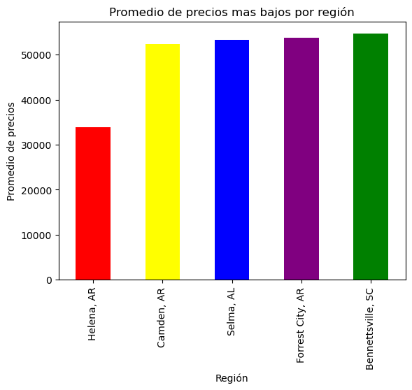

```python
colores = ['red', 'yellow', 'blue', 'purple', 'green']

# utilizamos el método 'plot' con el argumento kind='bar' para crear un gráfico de barras
df4.plot(x='RegionName', y='PriceMean', kind='bar', legend=False, color=colores)

# agregamos título y etiquetas a los ejes
plt.title("Promedio de precios mas bajos por región")
plt.xlabel("Región")
plt.ylabel("Promedio de precios")

# mostramos el gráfico
plt.show()
```

#### Este segmento de código guarda los DataFrames 'df3' y 'df4' en archivos CSV llamados "Promedio_Precios_Altos_Por_Region.csv" y "Promedio_Precios_Bajos_Por_Region.csv" respectivamente, los índices no son guardados en los archivos CSV.

```python
df3.to_csv("Promedio_Precios_Altos_Por_Region.csv", index=False)
df4.to_csv("Promedio_Precios_Bajos_Por_Region.csv", index=False)
```